# An introduction to the R package ptmixed

Mirko Signorelli

[figure not shown]

# Introduction

## What’s ptmixed?

`ptmixed` is an `R` package that has been created to estimate the **Poisson-Tweedie mixed effects model** proposed in the following article:

Signorelli, Spitali and Tsonaka (2021). *Poisson-Tweedie mixed-effects model: a flexible approach for the analysis of longitudinal RNA-seq data*. Statistical Modelling, 21 (6), 520-545; DOI: 10.1177/1471082X20936017.

The Poisson-Tweedie mixed effects model is a generalized linear mixed model (GLMM) for count data that encompasses the negative binomial and Poisson GLMMs as special cases. It is particularly **suitable for the analysis of overdispersed count data**, because it allows to model **overdispersion**, **zero-inflation** and **heavy-tails** more flexibly than the negative binomial GLMM.

The package comprises not only functions for the estimation of the Poisson-Tweedie mixed model, but also functions for the estimation of the negative binomial and Poisson-Tweedie GLMs and of the negative binomial GLMM, alongside with some (simple) data visualization functions.

## Package installation

Even though `ptmixed` is available from `CRAN`, it includes a `Bioconductor` packages among its dependencies (`tweeDEseq`). This can create problems in the installation phase, since the usual `install.packages( )` only fetches `CRAN` dependencies, and not `Bioconductor` ones. Below I explain two alternative ways to successfully install `ptmixed`.

### Option 1: install Bioconductor dependencies directly

The `R` package `ptmixed` and all of its dependencies can be installed all in one go using:

```r
if (!require("BiocManager", quietly = TRUE))
    install.packages("BiocManager")
BiocManager::install('ptmixed')
```

### Option 2: install Bioconductor dependencies manually

Alternatively, you may choose to first install `tweeDEseq` using `BiocManager::install( )`, and then to install `ptmixed` and all of its CRAN dependencies using `install.packages( )`. To do so, you need to use

```r
# step 1: install tweeDEseq
if (!require("BiocManager", quietly = TRUE))
    install.packages("BiocManager")
BiocManager::install('tweeDEseq')
# step 2: install ptmixed and CRAN dependencies
install.packages('ptmixed')
```

## Loading the package

After having installed `ptmixed`, you can load the package with

```r
library(ptmixed)
```

## Get started

The package can be installed directly from CRAN using

```r
install.packages('ptmixed')
```

After installing the package, you can load its functionalities through

```r
library('ptmixed')
```

# An overview of the package functionalities

The package comprises different types of functions:

- functions for the estimation of the Poisson-Tweedie and negative binomial GLMMs: see `?ptmixed` and `?nbmixed`
- functions for the estimation of the Poisson-Tweedie and negative binomial GLMs: see `?ptglm` and `?nbglm`
- functions to summarize model fits: see `?summary.ptglmm` and `?summary.ptglm`
- a function that allows to carry out univariate and multivariate Wald tests: see `?wald.test`
- a function to compute the predicted random effects for a fitted Poisson-Tweedie or negative binomial GLMM: see `?ranef`
- functions for data visualization: see `?pmf` and `?make.spaghetti`

# A step by step example

In this section I am going to present a step by step example whose aim is to show how the `R` package `ptmixed` can be used to estimate the Poisson-Tweedie GLMM, as well as a few simpler models.

## Data preparation

All functions in the package assume that data are in the so-called “[long format](https://www.theanalysisfactor.com/wide-and-long-data/)”. Let’s generate an example dataset (already in long format) using the function `simulate_ptglmm`:

```r
example.df = simulate_ptglmm(n = 14, t = 4, seed = 1234,
                             beta = c(2.3, -0.9, -0.2, 0.5),
                             D = 1.5, a = -1,
                             sigma2 = 0.7)
data.long = example.df$data
head(data.long)
```

```
##    y id group time
## 1  6  1     0    0
## 2  0  1     0    1
## 3  2  1     0    2
## 4  1  1     0    3
## 5 10  2     0    0
## 6 10  2     0    1
```

In this example I have generated a dataset of 14 subjects with 4 repeated measurements each. `y` is the response variable, `id` denotes the subject identicator, `group` is a dummy variable and `time` is the time at which a measurement was taken.

## Data visualization

Before fitting a model, it is often useful to make a few plots to get a feeling of the data that you would like to model. Below I use two simple plots to visualize the distribution of the response variable and its relationship with the available covariates.

We can view the marginal distribution of the response variable `y` using the function `pmf`, and visualize the individual trajectories of subjects over time using the function `make.spaghetti`:

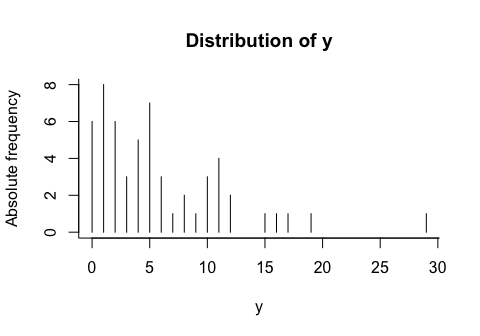

```r
pmf(data.long$y, xlab = 'y', title = 'Distribution of y')
```

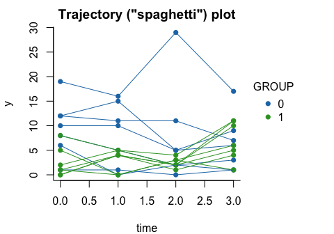

```r
make.spaghetti(x = time, y = y, id = id,
  group = group, data = data.long,
  title = 'Trajectory ("spaghetti") plot',
  legend.title = 'GROUP')
```

## The Poisson-Tweedie generalized linear mixed model

The most important function of the package, `ptmixed`, is a function that makes it possible to carry out **maximum likelihood (ML) estimation** of the Poisson-Tweedie GLMM. This function employs the adaptive Gauss-Hermite quadrature (AGHQ) method to evaluate the marginal likelihood of the GLMM, and then maximizes this likelihood using the Nelder-Mead and BFGS methods. Finally, if `hessian = T` (default value) a numerical evaluation of the hessian matrix (needed to compute the standard errors associated to the parameter estimates) in correspondance of the ML estimate is performed.

### Model Estimation

Estimation of the Poisson-Tweedie GLMM can be carried out using `ptmixed`:

```r
pt_glmm = ptmixed(fixef.formula = y ~ group*time, id = id,
                     data = data.long, npoints = 3,
                     hessian = T, trace = F)
```

```
##
##
## Total number of NM iterations = 570
## Convergence reached. Computing hessian...
```

The code above requires to estimate a GLMM

- with `y` as response, `group`, `time` and their interaction as fixed effects (as specified in `fixef.formula`), and a subject-specific random intercept (`id = id`)
- using an AGHQ with 3 quadrature points (`npoints = 3`)
- and to further evaluate the Hessian matrix at the MLE (`hessian = T`)

Note that the function comprises several other arguments, detailed in the function’s help page. In particular, there are four remarks that I’d like to make here:

- an offset term, if relevant, can be included through the `offset` argument
- a higher number of quadrature points can be specified by changing the value of `npoints` (my recommendation is to use `npoints = 5`)
- detailed information about the optimization can be printed on screen by specifying `trace = T` (here I have set `trace = F` to prevent a long tracing output to be printed in the middle of the vignette)
- ML estimation for this model is not trivial, and optimizations may sometimes fail to converge. If this happens, you may try to use a different number of quadrature points (`npoints`), to change the default values of the arguments `freq.updates`, `reltol`, `maxit` and `min.var.init`, or to supply an alternative (sensibly chosen) starting value (`theta.start`)

### Viewing parameter estimates, standard errors and p-values

The results of the fitted model can be viewed using

```r
summary(pt_glmm)
```

```
## Loglikelihood: -140.623
## Parameter estimates:
##             Estimate Std. error       z p.value
## (Intercept)   2.0059     0.2865  7.0010  0.0000
## group        -1.4523     0.4641 -3.1292  0.0018
## time         -0.1359     0.0762 -1.7826  0.0746
## group:time    0.5105     0.1458  3.5019  0.0005
##
## Dispersion = 1.63
## Power = -0.23
## Variance = 0.41
```

that reports the ML estimates of the regression coefficients (column `Estimate`), the associated standard errors (column `Std. error`) and univariate Wald tests (columns `z` and `p.value`), as well as the ML estimates of the dispersion and power parameters of the Poisson-Tweedie distribution, and the ML estimate of the variance of the random effects.

### Testing more complex hypotheses

More complex hypotheses can be tested using the multivariate Wald test or, when possible, the likelihood ratio test.

For example, one may want to test the null hypothesis that there are no differences between the two groups, that is to say that the regression coefficients of `group` and `group:time` are both = 0.

To test this hypothesis with the **multivariate Wald test**, we first need to specify it in the form $L \beta = 0$, where $L$ is specified as follows:

```r
L.group = matrix(0, nrow = 2, ncol = 4)
L.group[1, 2] = L.group[2, 4] = 1
L.group
```

```
##      [,1] [,2] [,3] [,4]
## [1,]    0    1    0    0
## [2,]    0    0    0    1
```

Then, we can proceed with computing the multivariate Wald test:

```r
wald.test(pt_glmm, L = L.group, k = c(0, 0))
```

```
##       chi2 df            P
## 1 14.22634  2 0.0008143105
```

Alternatively, the same hypothesis can be tested using the **likelihood ratio test** (LRT). To do so, you first need to estimate the model under the null hypothesis (note that for the purpose of this computation, evaluating the hessian matrix is not necessary, so we can avoid to compute it by setting `hessian = F`):

```r
null_model = ptmixed(fixef.formula = y ~ time, id = id,
                               data = data.long, npoints = 3,
                               hessian = F, trace = F)
```

```
##
##
## Total number of NM iterations = 398
```

Then, we can proceed to compare the null and alternative model by computing the LRT test statistic, whose asymptotic distribution is in this case a chi-squared with two degrees of freedom, and the corresponding p-value:

```r
lrt.stat = 2*(pt_glmm$logl - null_model$logl)
lrt.stat
```

```
## [1] 14.17753
```

```r
p.lrt = pchisq(lrt.stat, df = 2, lower.tail = F)
p.lrt
```

```
## [1] 0.0008344269
```

### Computing the predicted random effects

To computate the **predicted random effects**, simply use

```r
ranef(pt_glmm)
```

```
##           1           2           3           4           5           6
## -0.74838728  0.31472249  1.13391844 -1.17000951  0.49289844  0.40439346
##           7           8           9          10          11          12
## -0.22676683  0.31639414 -0.35419327 -0.02760355  0.17689645 -0.27431201
##          13          14
## -0.18584234  0.65265844
```

## Simpler models

The Poisson-Tweedie GLMM is an extension of three simpler models:

- negative binomial GLMM (this is obtained by fixing the power parameter a = 0)
- Poisson-Tweedie GLM (this is obtained by removing the random effects from the model)
- negative binomial GLM (this is obtained by fixing the power parameter a = 0 and removing the random effects from the model)

For this reason, the package also offers the possibility to estimate these simpler models, as illustrated below.

### Negative binomial generalized linear mixed model

The syntax to estimate the **negative binomial GLMM** is the same as that used for the Poisson-Tweedie GLMM. Just make sure to replace the function `ptmixed` with `nbmixed`:

```r
nb_glmm = nbmixed(fixef.formula = y ~ group*time, id = id,
                     data = data.long, npoints = 3,
                     hessian = T, trace = F)
```

```
##
## Total number of iterations = 362
## Convergence reached. Computing hessian...
```

To view the model summary and compute the predicted random effects, once again you can use

```r
summary(nb_glmm)
```

[output not shown]

```r
ranef(nb_glmm)
```

```
##           1           2           3           4           5           6
## -0.73856990  0.33249113  1.15104776 -1.16599968  0.51121344  0.42102715
##           7           8           9          10          11          12
## -0.21148564  0.31620528 -0.35946848 -0.02816143  0.17458088 -0.27611762
##          13          14
## -0.18756259  0.65244576
```

### Poisson-Tweedie generalized linear model

Estimation of the **Poisson-Tweedie GLM** can be done using the `ptglm` function:

```r
pt_glm = ptglm(formula = y ~ group*time, data = data.long, trace = F)
summary(pt_glm)
```

```
## Loglikelihood: -152.931
## Parameter estimates:
##             Estimate Std. error       z p.value
## (Intercept)   2.2396     0.2128 10.5265  0.0000
## group        -1.3792     0.4083 -3.3778  0.0007
## time         -0.1661     0.1244 -1.3353  0.1818
## group:time    0.5111     0.2046  2.4984  0.0125
##
## Dispersion = 4.24
## Power = -0.16
```

### Negative binomial generalized linear model

Finally, estimation of the **negative binomial GLM** can be done using the `nbglm` function:

```r
nb_glm = nbglm(formula = y ~ group*time, data = data.long, trace = F)
summary(nb_glm)
```

```
## Loglikelihood: -152.955
## Parameter estimates:
##             Estimate Std. error       z p.value
## (Intercept)   2.2401     0.2146 10.4362  0.0000
## group        -1.3751     0.4070 -3.3788  0.0007
## time         -0.1701     0.1241 -1.3701  0.1707
## group:time    0.5170     0.2030  2.5473  0.0109
##
## Dispersion = 4.37
## Power = 0
```

# Further details and material

The aim of this vignette is to provide a quick-start introduction to the `R` package `ptmixed`. Here I have focused my attention on the fundamental aspects that one needs to use the package.

Further details, functions and examples can be found in [the manual of the package](https://CRAN.R-project.org/package=ptmixed/ptmixed.pdf).

The description of the method is available in an article [that you can read here](https://journals.sagepub.com/doi/pdf/10.1177/1471082X20936017).